# Customizing Data Visualizations

## Introduction

In the *Basics of ggplot* tutorial, you learned the basics of `ggplot2`, the tidyverse’s primary package for creating data visualizations. In this tutorial, we will focus on different ways you can customize your data visualizations.

### Learning objectives

By the end of this tutorial, you should be able to

- Add aesthetics to a plot
- Change the limits on the x and y axis
- Change the color palette
- Apply a theme to a plot
- Arrange multiple plots in a grid

## The Data

We will use the `mtcars` data set, which is automatically loaded when you open RStudio. The data is from the 1974 *Motor Trend* magazine, and it contains performance information and other specifications for 32 automobiles made in 1973 and 1974.

To learn more about the data set and the variable definitions, type the following code in the console:

```r
?mtcars
```

We will make a few small changes to the `mtcars` data frame to prepare it for visualization:

```r
mtcars <- mtcars %>%
  mutate(am = factor(am),
         cyl = factor(cyl),
         vs = factor(vs))
```

We create data visualizations using the `ggplot2` package. It is one of the core `tidyverse` packages, so it loads automatically when we run the code below.

```r
library(tidyverse)
```

## The basic plot

Let’s start with a scatterplot displaying the relationship between horsepower (`hp`) and miles per gallon (`mpg`).

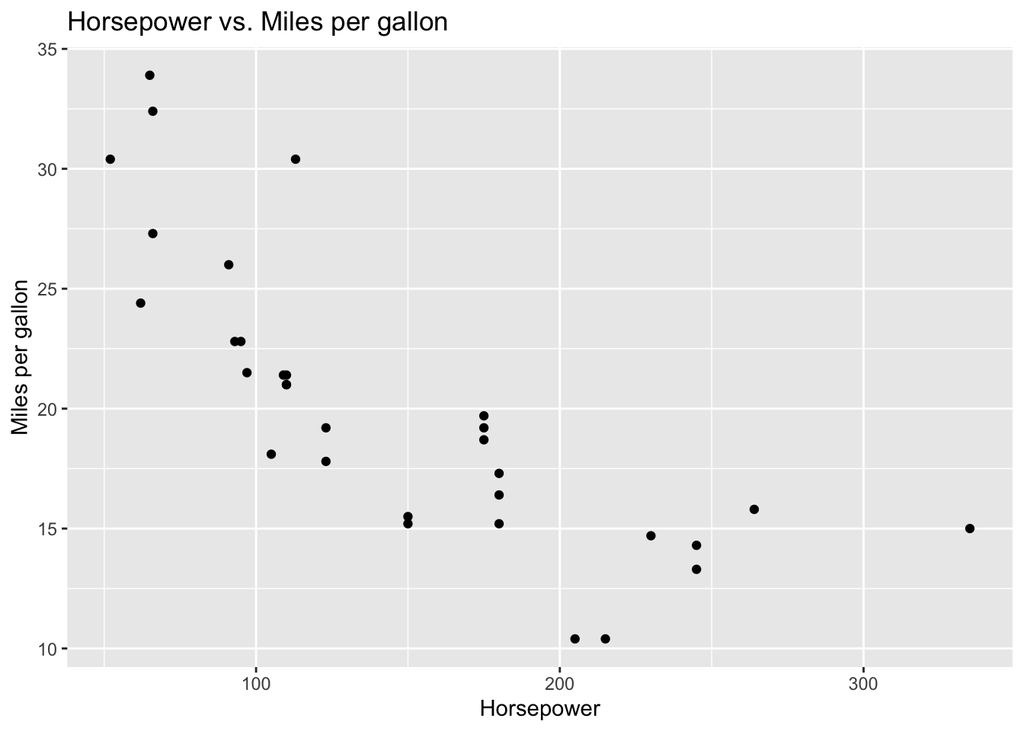

```r
ggplot(data = mtcars, aes(x = hp, y = mpg)) +
  geom_point() +
  labs(x = "Horsepower",
       y = "Miles per gallon",
       title = "Horsepower vs. Miles per gallon")
```

Using this as a baseline, let’s customize the plot!

## Aesthetics

We can add aesthetics (features) to our plot to incorporate additional variables or to customize the plot. These aesthetics include

- `color`
- `shape`
- `size`
- `alpha` (transparency)

Aesthetics can be mapped in two different ways:

1. Aesthetic based on value of a variable. Aesthetic defined inside `aes()`.
2. Same aesthetic for all observations. Defined in the `geom_**` outside of `aes()`.

Let’s look at two plots in which the `color` aesthetic is applied in both ways:

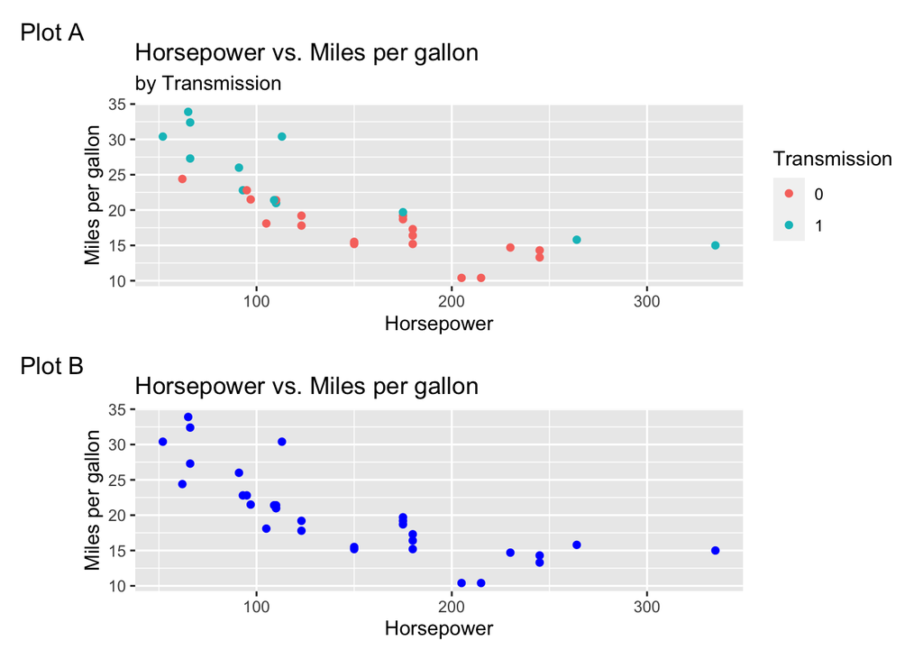

Notice in **Plot A** that the color of the points is based on the type of transmission (`am`). Using color in this way, we have added additional information to the plot, as we can now see the relationship between miles per gallon and horsepower for each transmission type.

Let’s look at the code for **Plot A**.

Notice how the code used to define the color is inside of the `aes` function. This tells R to color the points based on the type of transmission (`am`). In other words, the color aesthetic is assigned to `am`. We have also added a label to the legend and a subtitle.

*Note: When we add labels, we map a label to each aesthetic. For example, the code `color = "Transmission"` within the `labs()` function doesn’t change the color of the points by Transmission but merely applies the label “Transmission” to the color legend. (Without this label, the legend would be titled `am` which may be confusing to some readers.)*

```
ggplot(data = mtcars, aes(x = hp, y = mpg, color = am)) +
  geom_point() +
  labs(x = "Horsepower",
       y = "Miles per gallon",
       color = "Transmission",
       title = "Horsepower vs. Miles per gallon",
       subtitle = "by Transmission")
```

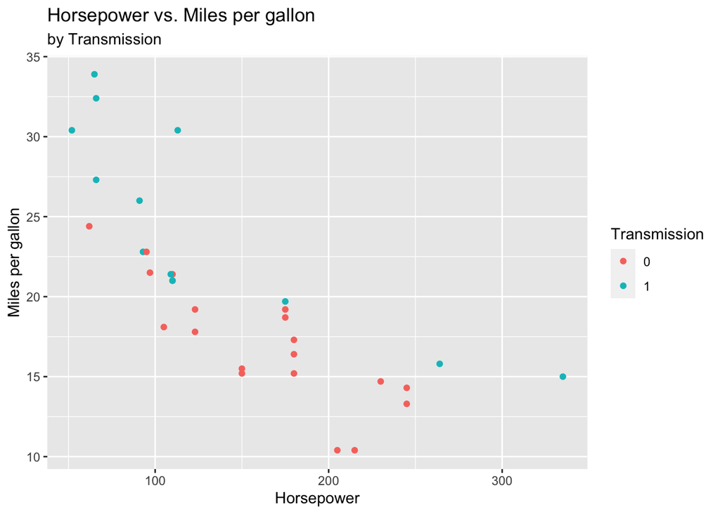

Now, let’s take a look at the code for **Plot B**.

Here, we have assigned the same color aesthetic to all points on the plot. Since we want to use the same color for all points, we define the color in the `geom_**` outside of the `aes` function. In this case, we haven’t added any new information, but we’re just using color to change how the plot looks.

```
ggplot(data = mtcars, aes(x = hp, y = mpg)) +
  geom_point(color = "blue") +
  labs(x = "Horsepower",
       y = "Miles per gallon",
       title = "Horsepower vs. Miles per gallon")
```

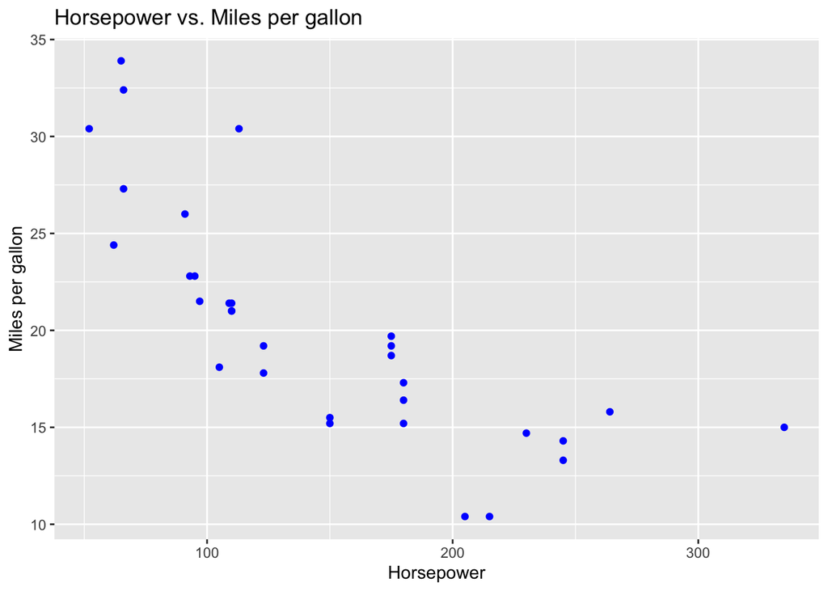

### Your turn!

1. Fill in the code below to create a scatterplot such that the shape of the points is based on the number of cylinders (`cyl`) and all points are a size 2.

```r
ggplot(data = mtcars, aes(x = hp, y = mpg, ___)) +
  geom_point(___) +
  labs(x = "Horsepower",
       y = "Miles per gallon",
       ___,
       title = "Horsepower vs. Miles per gallon")
```

2. Fill in the code below to create a scatterplot of miles per gallon versus horsepower such that all points have an alpha of 0.5 and the size is determined by the number of forward gears (`gear`).

```r
ggplot(data = mtcars, aes(x = ___, y = ___, ___)) +
  geom_point(___) +
  labs(x = "Horsepower",
       y = "Miles per gallon",
       ___,
       title = "Horsepower vs. Miles per gallon")
```

## Change axis limits

Let’s stick with **Plot A** for now.

Another way to customize the plot is to change the limits on the x and y axes. Suppose we want to zoom in on a portion of the plot. Let’s change the axes to do so.

```
ggplot(data = mtcars, aes(x = hp, y = mpg, color = am)) +
  geom_point() +
  labs(x = "Horsepower",
       y = "Miles per gallon",
       color = "Transmission",
       title = "Horsepower vs. Miles per gallon",
       subtitle = "by Transmission") +
  xlim(c(100, 300)) +
  ylim(c(15, 25))
```

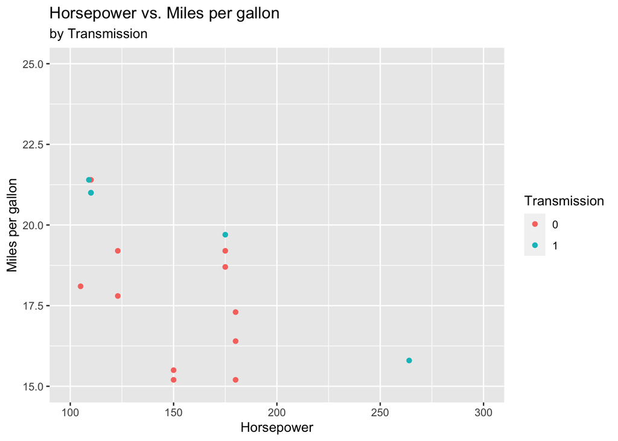

## Change color palette

Another way to customize a plot is to change the color palette. The default color palette used in `ggplot2` is not color-blind safe, so it is good practice to change the color palette if you wish to present your results to a large audience.

Let’s look at a plot of the Miles per gallon vs. Horsepower colored by the cylinders.

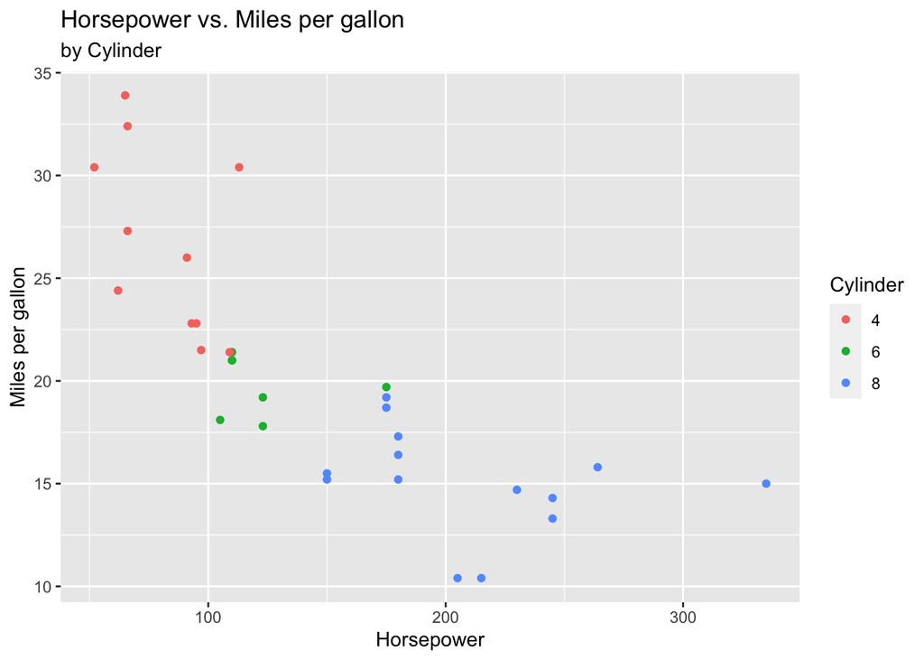

```r
ggplot(data = mtcars, aes(x = hp, y = mpg, color = cyl)) +
  geom_point() +
  labs(x = "Horsepower",
       y = "Miles per gallon",
       color = "Cylinder",
       title = "Horsepower vs. Miles per gallon",
       subtitle = "by Cylinder")
```

This is the default color palette in `ggplot2`; however, we may want to use something different. One way to do this is by using the `scale_color_brewer` function. Using this function, we specify a palette from [RColorBrewer](https://www.r-graph-gallery.com/38-rcolorbrewers-palettes.html).

Here is the same plot above using the “Dark2” color palette:

```
ggplot(data = mtcars, aes(x = hp, y = mpg, color = cyl)) +
  geom_point() +
  labs(x = "Horsepower",
       y = "Miles per gallon",
       color = "Cylinder",
       title = "Horsepower vs. Miles per gallon",
       subtitle = "by Cylinder") +
  scale_color_brewer(palette = "Dark2")
```

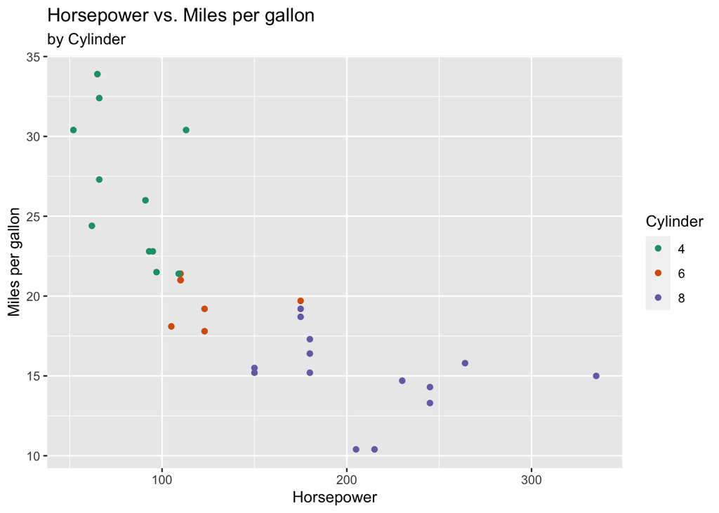

Another option for color palettes are those available in the `viridis` package. All palettes in this package are colorblind safe.

```
library(viridis)

ggplot(data = mtcars, aes(x = hp, y = mpg, color = cyl)) +
  geom_point() +
  labs(x = "Horsepower",
       y = "Miles per gallon",
       color = "Cylinder",
       title = "Horsepower vs. Miles per gallon",
       subtitle = "by Cylinder") +
   scale_color_viridis(discrete = TRUE) # for discrete color scale
```

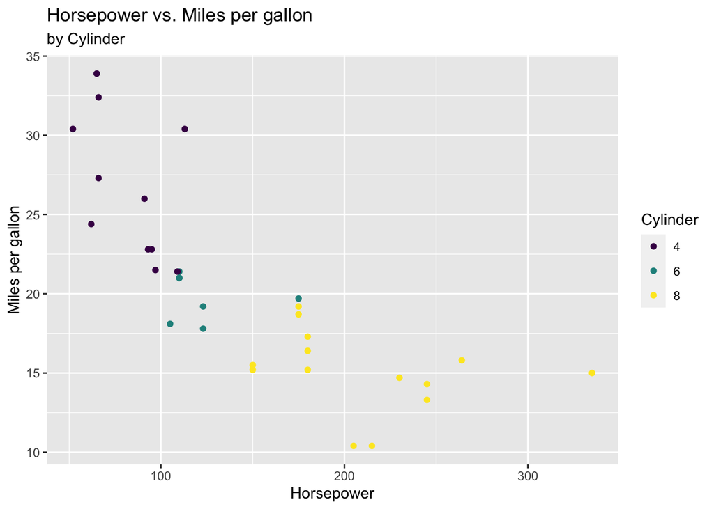

Click [here](https://www.datanovia.com/en/blog/top-r-color-palettes-to-know-for-great-data-visualization/) to find a full list of color palettes available to use in `scale_color_brewer` and `scale_color_viridis`.

### Your turn!

1. Fill in the code below to try different color palettes available in [RColorBrewer](https://www.r-graph-gallery.com/38-rcolorbrewers-palettes.html).

```r
ggplot(data = mtcars, aes(x = hp, y = mpg, color = cyl)) +
  geom_point() +
  labs(x = "Horsepower",
       y = "Miles per gallon",
       color = "Cylinder",
       title = "Horsepower vs. Miles per gallon",
       subtitle = "by Cylinder") +
  scale_color_brewer(palette = "___")
```

2. Fill in the code below to try different palettes available in the [`scale_color_viridis`] (https://www.datanovia.com/en/blog/top-r-color-palettes-to-know-for-great-data-visualization/) function.

```r
ggplot(data = mtcars, aes(x = hp, y = mpg, color = cyl)) +
  geom_point() +
  labs(x = "Horsepower",
       y = "Miles per gallon",
       color = "Cylinder",
       title = "Horsepower vs. Miles per gallon",
       subtitle = "by Cylinder") +
  scale_colour_viridis(palette = "___")
```

## Themes

We may want to change the overall look of the visualization, e.g. the background, grid lines, etc. One way to do this is by applying a theme to the visualization.

### Themes in `ggplot2` package

There is a collection of [complete themes](https://ggplot2.tidyverse.org/reference/ggtheme.html) available in the `ggplot2` package. Let’s take a look at two the themes: `theme_dark` and `theme_classic`.

```
ggplot(data = mtcars, aes(x = hp, y = mpg, color = am)) +
  geom_point() +
  labs(x = "Horsepower",
       y = "Miles per gallon",
       color = "Transmission",
       title = "Horsepower vs. Miles per gallon",
       subtitle = "by Transmission") +
 theme_dark()
```

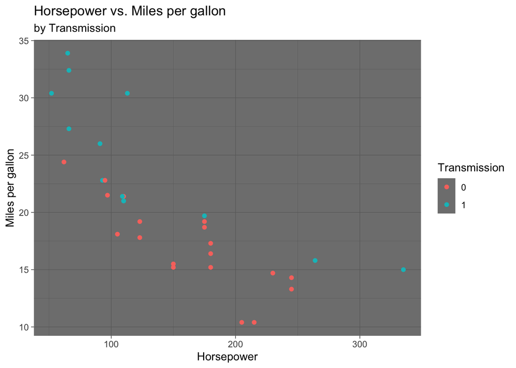

```
ggplot(data = mtcars, aes(x = hp, y = mpg, color = am)) +
  geom_point() +
  labs(x = "Horsepower",
       y = "Miles per gallon",
       color = "Transmission",
       title = "Horsepower vs. Miles per gallon",
       subtitle = "by Transmission") +
 theme_classic()
```

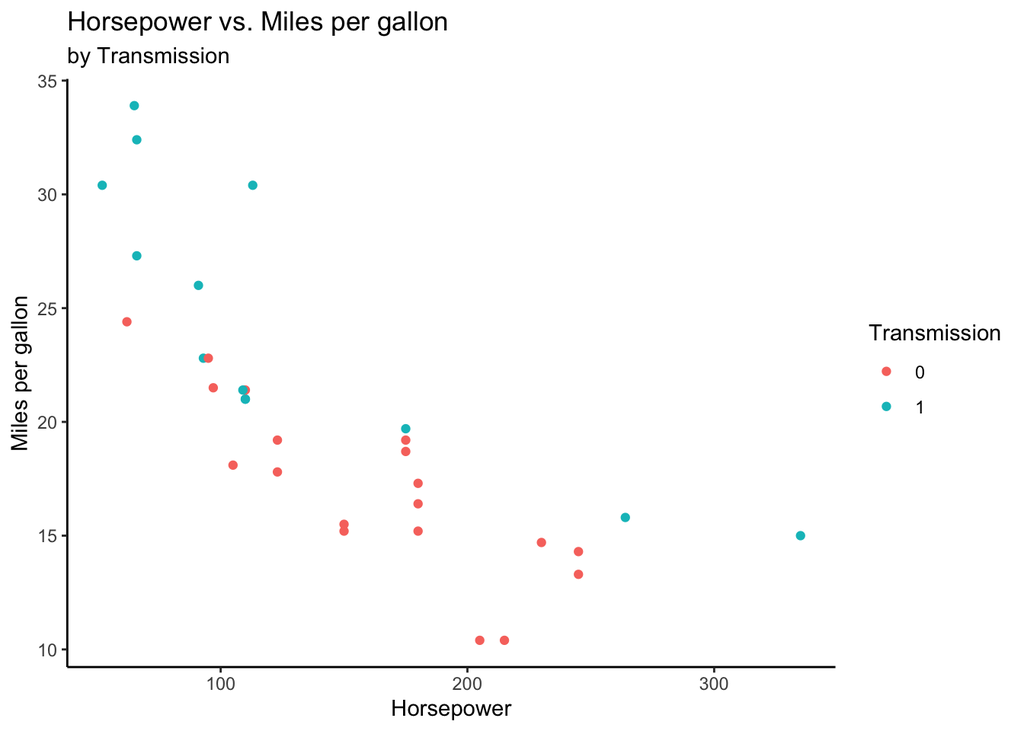

A list of complete themes available in the `ggplot2` package can be found [here](https://ggplot2.tidyverse.org/reference/ggtheme.html).

You can also customize individual elements of a visualization by using the `theme` function. One instance in which this function is especially useful is to update the font size of the axis labels and title.

```
ggplot(data = mtcars, aes(x = hp, y = mpg, color = am)) +
  geom_point() +
  labs(x = "Horsepower",
       y = "Miles per gallon",
       color = "Transmission",
       subtitle = "by Transmission",
       title = "Horsepower vs. Miles per gallon") +
 theme(plot.title = element_text(size = 20),
       axis.title.x = element_text(size = 16),
       axis.title.y = element_text(size = 16))
```

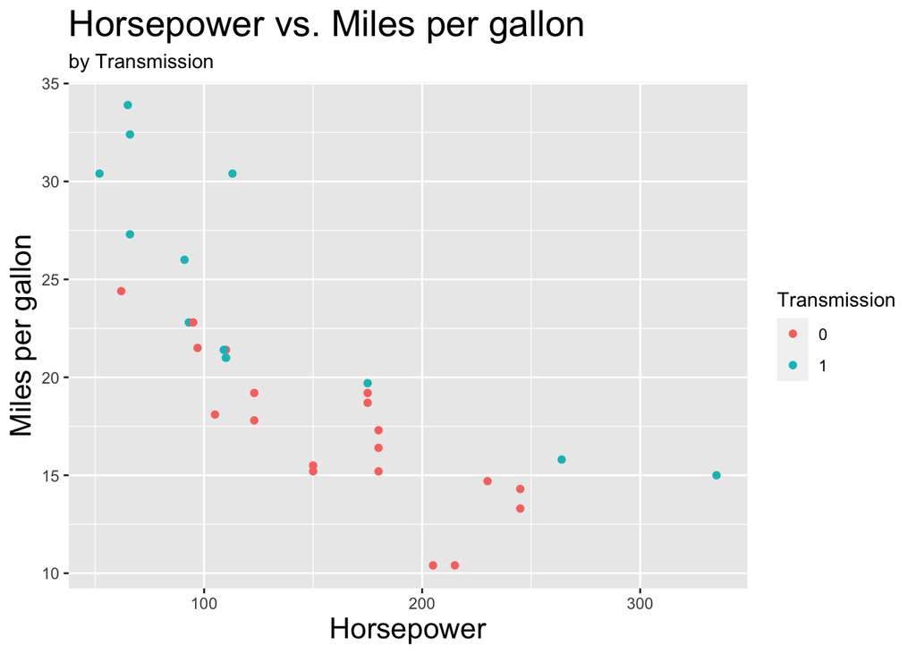

See the [`theme` reference page](https://ggplot2.tidyverse.org/reference/theme.html) to learn more about customizing individual elements of a plot.

### `ggthemes` package

The `ggthemes` package has a selection of custom themes and color palettes. You can find all of the themes and palettes on the [`ggthemes` webpage](https://yutannihilation.github.io/allYourFigureAreBelongToUs/ggthemes/).

Here is an example of their FiveThirtyEight theme. Note that you need to load the `ggthemes` package.

```
library(ggthemes)

ggplot(data = mtcars, aes(x = hp, y = mpg, color = am)) +
  geom_point() +
  labs(x = "Horsepower",
       y = "Miles per gallon",
       color = "Transmission",
       subtitle = "by Transmission",
       title = "Horsepower vs. Miles per gallon") +
 theme_fivethirtyeight()
```

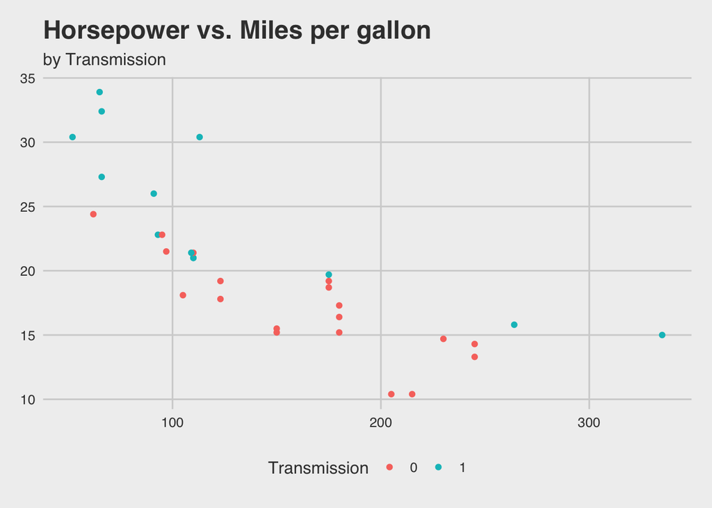

### Your turn!

Apply a new theme to a plot of your choice. You can create your own plot or use code from one of the plots in this tutorial. Try a few different themes - from `ggplot2` and from `ggthemes`.

### Patchwork

Sometimes we want to organize multiple plots in a grid to more neatly format them in a write up or presentation. This can be especially helpful if you have a lot of plots to display (for example, when doing exploratory data analysis).

We can use the `patchwork` package to arrange plots in rows and columns.

Let’s suppose we have the following three plots assigned to names `p1`, `p2`, and `p3`:

```r
p1 <- ggplot(data = mtcars, aes(x = cyl)) +
  geom_bar() +
  labs(x = "Number of Cylinders")

p2 <- ggplot(data = mtcars, aes(x = hp)) +
  geom_histogram() +
  labs(x = "Horsepower",
       y = "Count")

p3 <- ggplot(data = mtcars, aes(x = hp, y = mpg, color = am)) +
  geom_point() +
  labs(x = "Horsepower",
       y = "Miles per gallon",
       color = "Transmission")
```

Use `/` to put a plot on a new row:

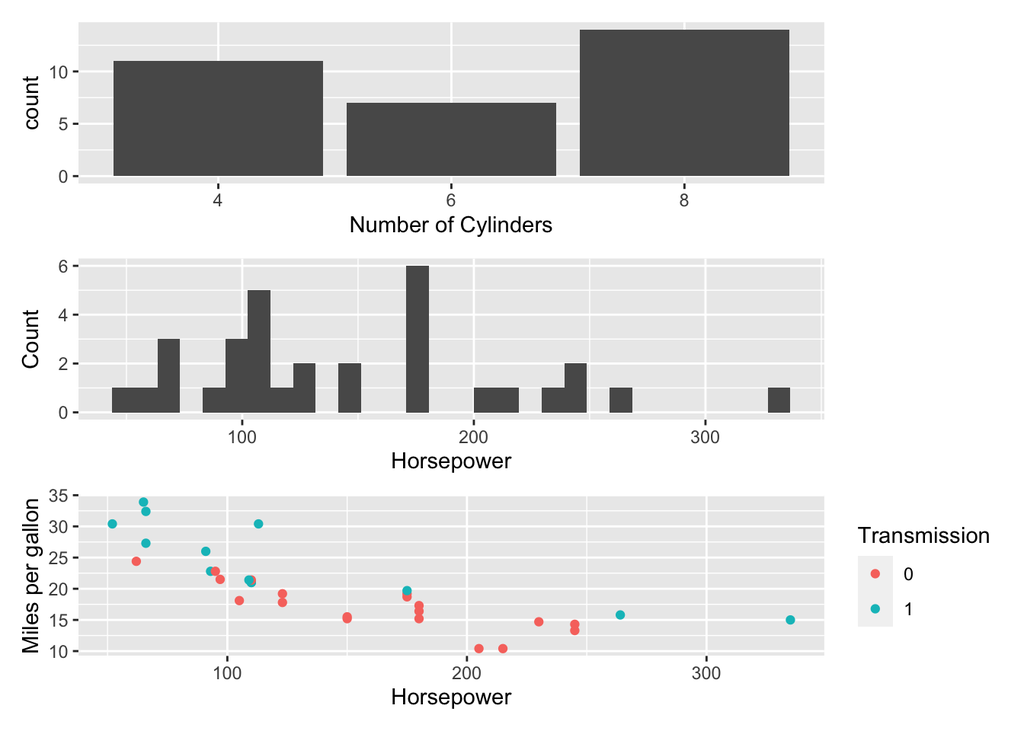

```r
p1 / p2 / p3
```

Use `+` to put a plot in a new column:

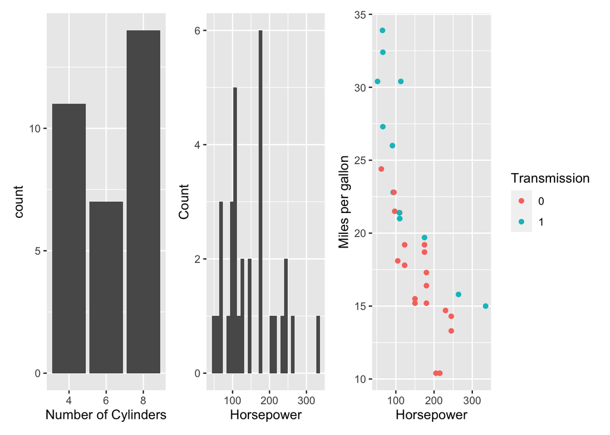

```r
p1 + p2 + p3
```

Use a combination of `/` and `+` to arrange the plots in rows and columns. Let’s put `p1` and `p2` on the first row and `p3` on the second row:

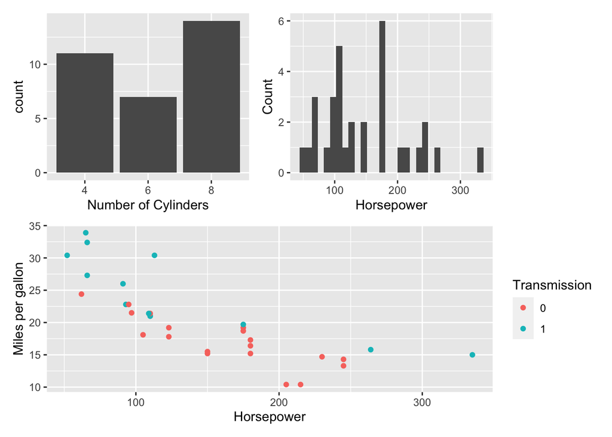

```r
(p1 + p2) / p3
```

Let’s repeat the code above without the parentheses. Notice how the arrangement these plots differ from the arrangement above.

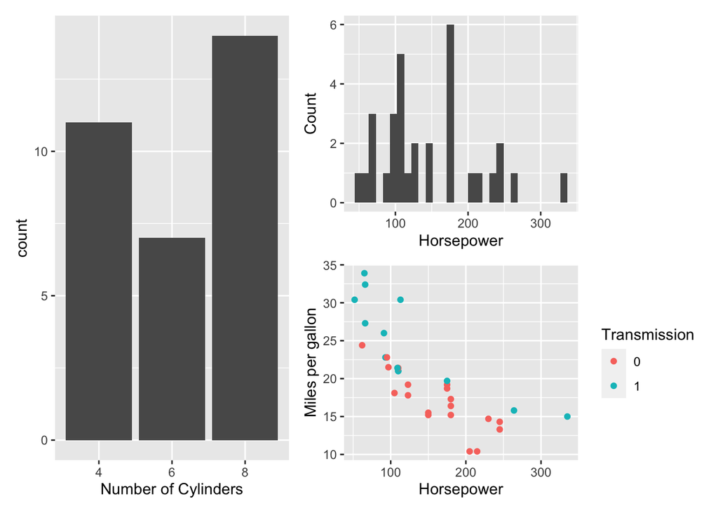

```r
p1 + p2 / p3
```

Just like the “order of operations” from math, the `/` will be applied before `+`. Use parentheses (as in the code above) to apply the `+` first.

Finally, we can use the `plot_annotation()` function to add labels and other text annotations to patchwork objects. Using the code below, we use letters to label each plot.

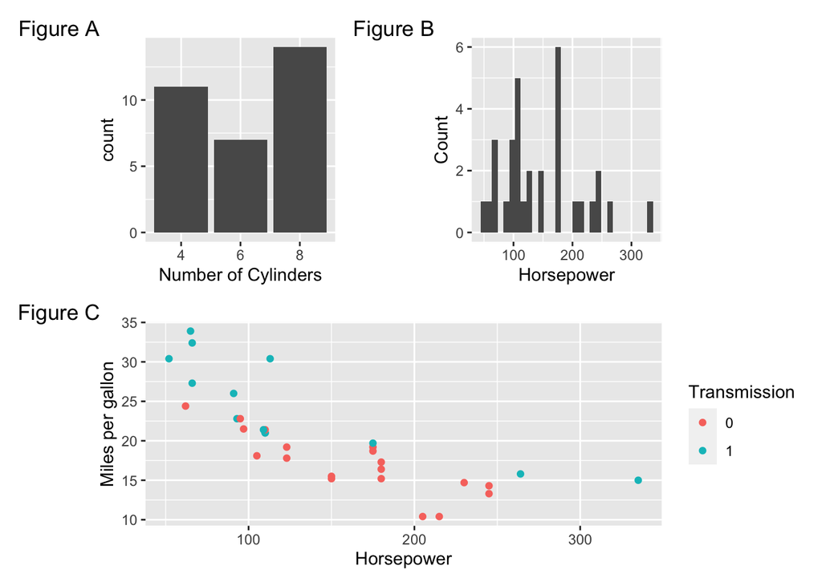

```r
(p1 + p2) / p3 +
  plot_annotation(tag_levels = "A", tag_prefix = "Figure ")
```

### Your turn!

Use the patchwork function to arrange `p1`, `p2`, and `p3` in the following configuration:

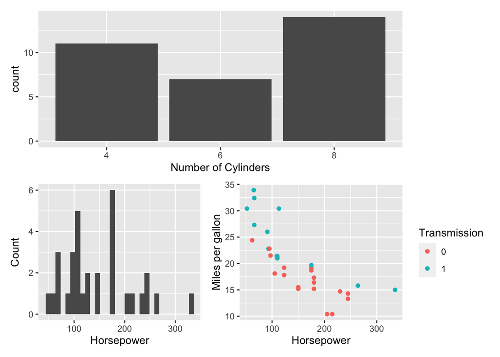

## Resources

- https://ggplot2.tidyverse.org/
- https://patchwork.data-imaginist.com/index.html
- [R for Data Science: Data visualization](https://r4ds.had.co.nz/data-visualisation.html)
- ggplot2: Elegant Graphics for Data Analysis